# Exploratory Data Analysis of Developer Survey Results

**Author:** Arturo Alejandro Díaz Barbosa  
**Date:** June, 2025

**Data Source:**  
Stack Overflow Developer Survey 2024  
(https://survey.stackoverflow.co/2024/)

## Dataset Description

Stack Overflow, the go-to platform for developers, conducted a global survey to capture insights into the developer community. This survey includes various questions related to professional experience, coding activities, tools, technologies, and preferences. The dataset offers important information about the current state of software development worldwide and covers topics such as demographics, salary, education, career paths, and technology usage.

## Objective

This project aims to explore the responses from the 2024 Stack Overflow Developer Survey to answer key questions such as:

1. How does average salary vary with years of experience?
2. Which programming languages are most used by region?
3. Is there a correlation between education level and annual salary?

## *Import required libraries*

```python
import pandas as pd
import numpy as np
import matplotlib.pyplot as plt
import seaborn as sns
import plotly.express as px
from sklearn.preprocessing import MinMaxScaler
```

## Initial Data Loading and Cleaning

- Load raw survey data from CSV and preview its structure and size.
- Extract a subset of relevant columns for analysis.
- Explore the data with summary statistics and data types.
- Check for missing values and duplicated rows.
- Remove duplicates to ensure data quality before further analysis.

#### *Load CSV data into DataFrame*

```python
df_raw = pd.read_csv('survey_data.csv', low_memory=False) # Read CSV into DataFrame
df_raw.head() # Show first 5 rows of DataFrame
```

|  | ResponseId | MainBranch | Age | Employment | RemoteWork | Check | CodingActivities | EdLevel | LearnCode | LearnCodeOnline | ... | JobSatPoints_6 | JobSatPoints_7 | JobSatPoints_8 | JobSatPoints_9 | JobSatPoints_10 | JobSatPoints_11 | SurveyLength | SurveyEase | ConvertedCompYearly | JobSat |
| --- | --- | --- | --- | --- | --- | --- | --- | --- | --- | --- | --- | --- | --- | --- | --- | --- | --- | --- | --- | --- | --- |
| 0 | 1 | I am a developer by profession | Under 18 years old | Employed, full-time | Remote | Apples | Hobby | Primary/elementary school | Books / Physical media | NaN | ... | NaN | NaN | NaN | NaN | NaN | NaN | NaN | NaN | NaN | NaN |
| 1 | 2 | I am a developer by profession | 35-44 years old | Employed, full-time | Remote | Apples | Hobby;Contribute to open-source projects;Other... | Bachelor’s degree (B.A., B.S., B.Eng., etc.) | Books / Physical media;Colleague;On the job tr... | Technical documentation;Blogs;Books;Written Tu... | ... | 0.0 | 0.0 | 0.0 | 0.0 | 0.0 | 0.0 | NaN | NaN | NaN | NaN |
| 2 | 3 | I am a developer by profession | 45-54 years old | Employed, full-time | Remote | Apples | Hobby;Contribute to open-source projects;Other... | Master’s degree (M.A., M.S., M.Eng., MBA, etc.) | Books / Physical media;Colleague;On the job tr... | Technical documentation;Blogs;Books;Written Tu... | ... | NaN | NaN | NaN | NaN | NaN | NaN | Appropriate in length | Easy | NaN | NaN |
| 3 | 4 | I am learning to code | 18-24 years old | Student, full-time | NaN | Apples | NaN | Some college/university study without earning ... | Other online resources (e.g., videos, blogs, f... | Stack Overflow;How-to videos;Interactive tutorial | ... | NaN | NaN | NaN | NaN | NaN | NaN | Too long | Easy | NaN | NaN |
| 4 | 5 | I am a developer by profession | 18-24 years old | Student, full-time | NaN | Apples | NaN | Secondary school (e.g. American high school, G... | Other online resources (e.g., videos, blogs, f... | Technical documentation;Blogs;Written Tutorial... | ... | NaN | NaN | NaN | NaN | NaN | NaN | Too short | Easy | NaN | NaN |

5 rows × 114 columns

#### *Returns the number of rows and columns in the DataFrame.*

```python
df_raw.shape
```

```
(65437, 114)
```

#### *Returns a list of column names in the DataFrame.*

```python
df_raw.columns.to_list()
```

```
['ResponseId',
 'MainBranch',
 'Age',
 'Employment',
 'RemoteWork',
 'Check',
 'CodingActivities',
 'EdLevel',
 'LearnCode',
 'LearnCodeOnline',
 'TechDoc',
 'YearsCode',
 'YearsCodePro',
 'DevType',
 'OrgSize',
 'PurchaseInfluence',
 'BuyNewTool',
 'BuildvsBuy',
 'TechEndorse',
 'Country',
 'Currency',
 'CompTotal',
 'LanguageHaveWorkedWith',
 'LanguageWantToWorkWith',
 'LanguageAdmired',
 'DatabaseHaveWorkedWith',
 'DatabaseWantToWorkWith',
 'DatabaseAdmired',
 'PlatformHaveWorkedWith',
 'PlatformWantToWorkWith',
 'PlatformAdmired',
 'WebframeHaveWorkedWith',
 'WebframeWantToWorkWith',
 'WebframeAdmired',
 'EmbeddedHaveWorkedWith',
 'EmbeddedWantToWorkWith',
 'EmbeddedAdmired',
 'MiscTechHaveWorkedWith',
 'MiscTechWantToWorkWith',
 'MiscTechAdmired',
```

[output cut: 59 more lines]

```
 'ProfessionalQuestion',
 'Industry',
 'JobSatPoints_1',
 'JobSatPoints_4',
 'JobSatPoints_5',
 'JobSatPoints_6',
 'JobSatPoints_7',
 'JobSatPoints_8',
 'JobSatPoints_9',
 'JobSatPoints_10',
 'JobSatPoints_11',
 'SurveyLength',
 'SurveyEase',
 'ConvertedCompYearly',
 'JobSat']
```

#### *Creates a new DataFrame `df` by selecting specific columns*

```python
df = df_raw[['Age', 'Employment', 'WorkExp', 'RemoteWork', 'CodingActivities', 'EdLevel',
             'YearsCode', 'DevType', 'Country', 'ConvertedCompYearly', 'LanguageHaveWorkedWith', 'LanguageWantToWorkWith',
            'LanguageAdmired', 'DatabaseHaveWorkedWith', 'DatabaseWantToWorkWith', 'PlatformHaveWorkedWith', 'PlatformWantToWorkWith',
            'WebframeHaveWorkedWith', 'WebframeWantToWorkWith', 'OpSysProfessional use', 'Industry', 'JobSat']]
```

#### *Display first rows of the new DataFrame*

```python
df.head()  # Show first 5 rows of DataFrame
```

|  | Age | Employment | WorkExp | RemoteWork | CodingActivities | EdLevel | YearsCode | DevType | Country | ConvertedCompYearly | ... | LanguageAdmired | DatabaseHaveWorkedWith | DatabaseWantToWorkWith | PlatformHaveWorkedWith | PlatformWantToWorkWith | WebframeHaveWorkedWith | WebframeWantToWorkWith | OpSysProfessional use | Industry | JobSat |
| --- | --- | --- | --- | --- | --- | --- | --- | --- | --- | --- | --- | --- | --- | --- | --- | --- | --- | --- | --- | --- | --- |
| 0 | Under 18 years old | Employed, full-time | NaN | Remote | Hobby | Primary/elementary school | NaN | NaN | United States of America | NaN | ... | NaN | NaN | NaN | NaN | NaN | NaN | NaN | NaN | NaN | NaN |
| 1 | 35-44 years old | Employed, full-time | 17.0 | Remote | Hobby;Contribute to open-source projects;Other... | Bachelor’s degree (B.A., B.S., B.Eng., etc.) | 20 | Developer, full-stack | United Kingdom of Great Britain and Northern I... | NaN | ... | Bash/Shell (all shells);Go;HTML/CSS;Java;JavaS... | Dynamodb;MongoDB;PostgreSQL | PostgreSQL | Amazon Web Services (AWS);Heroku;Netlify | Amazon Web Services (AWS);Heroku;Netlify | Express;Next.js;Node.js;React | Express;Htmx;Node.js;React;Remix | MacOS | NaN | NaN |
| 2 | 45-54 years old | Employed, full-time | NaN | Remote | Hobby;Contribute to open-source projects;Other... | Master’s degree (M.A., M.S., M.Eng., MBA, etc.) | 37 | Developer Experience | United Kingdom of Great Britain and Northern I... | NaN | ... | C# | Firebase Realtime Database | Firebase Realtime Database | Google Cloud | Google Cloud | ASP.NET CORE | ASP.NET CORE | Windows | NaN | NaN |
| 3 | 18-24 years old | Student, full-time | NaN | NaN | NaN | Some college/university study without earning ... | 4 | Developer, full-stack | Canada | NaN | ... | HTML/CSS;Java;JavaScript;PowerShell;Python;SQL... | MongoDB;MySQL;PostgreSQL;SQLite | MongoDB;MySQL;PostgreSQL | Amazon Web Services (AWS);Fly.io;Heroku | Amazon Web Services (AWS);Vercel | jQuery;Next.js;Node.js;React;WordPress | jQuery;Next.js;Node.js;React | NaN | NaN | NaN |
| 4 | 18-24 years old | Student, full-time | NaN | NaN | NaN | Secondary school (e.g. American high school, G... | 9 | Developer, full-stack | Norway | NaN | ... | C++;HTML/CSS;JavaScript;Lua;Python | PostgreSQL;SQLite | PostgreSQL;SQLite | NaN | NaN | NaN | NaN | NaN | NaN | NaN |

5 rows × 22 columns

#### *Generates descriptive statistics for all columns*

```python
df.describe(include='all')
```

|  | Age | Employment | WorkExp | RemoteWork | CodingActivities | EdLevel | YearsCode | DevType | Country | ConvertedCompYearly | ... | LanguageAdmired | DatabaseHaveWorkedWith | DatabaseWantToWorkWith | PlatformHaveWorkedWith | PlatformWantToWorkWith | WebframeHaveWorkedWith | WebframeWantToWorkWith | OpSysProfessional use | Industry | JobSat |
| --- | --- | --- | --- | --- | --- | --- | --- | --- | --- | --- | --- | --- | --- | --- | --- | --- | --- | --- | --- | --- | --- |
| count | 65437 | 65437 | 29658.000000 | 54806 | 54466 | 60784 | 59869 | 59445 | 58930 | 2.343500e+04 | ... | 50872 | 50254 | 42558 | 42366 | 34532 | 45161 | 38535 | 52973 | 28858 | 29126.000000 |
| unique | 8 | 110 | NaN | 3 | 118 | 8 | 52 | 34 | 185 | NaN | ... | 12335 | 9050 | 8478 | 5467 | 4784 | 12235 | 11654 | 2032 | 15 | NaN |
| top | 25-34 years old | Employed, full-time | NaN | Hybrid (some remote, some in-person) | Hobby | Bachelor’s degree (B.A., B.S., B.Eng., etc.) | 10 | Developer, full-stack | United States of America | NaN | ... | Python | PostgreSQL | PostgreSQL | Amazon Web Services (AWS) | Amazon Web Services (AWS) | React | React | Windows | Software Development | NaN |
| freq | 23911 | 39041 | NaN | 23015 | 9993 | 24942 | 4561 | 18260 | 11095 | NaN | ... | 1555 | 3216 | 3738 | 6606 | 4859 | 1284 | 997 | 10472 | 11918 | NaN |
| mean | NaN | NaN | 11.466957 | NaN | NaN | NaN | NaN | NaN | NaN | 8.615529e+04 | ... | NaN | NaN | NaN | NaN | NaN | NaN | NaN | NaN | NaN | 6.935041 |
| std | NaN | NaN | 9.168709 | NaN | NaN | NaN | NaN | NaN | NaN | 1.867570e+05 | ... | NaN | NaN | NaN | NaN | NaN | NaN | NaN | NaN | NaN | 2.088259 |
| min | NaN | NaN | 0.000000 | NaN | NaN | NaN | NaN | NaN | NaN | 1.000000e+00 | ... | NaN | NaN | NaN | NaN | NaN | NaN | NaN | NaN | NaN | 0.000000 |
| 25% | NaN | NaN | 4.000000 | NaN | NaN | NaN | NaN | NaN | NaN | 3.271200e+04 | ... | NaN | NaN | NaN | NaN | NaN | NaN | NaN | NaN | NaN | 6.000000 |
| 50% | NaN | NaN | 9.000000 | NaN | NaN | NaN | NaN | NaN | NaN | 6.500000e+04 | ... | NaN | NaN | NaN | NaN | NaN | NaN | NaN | NaN | NaN | 7.000000 |
| 75% | NaN | NaN | 16.000000 | NaN | NaN | NaN | NaN | NaN | NaN | 1.079715e+05 | ... | NaN | NaN | NaN | NaN | NaN | NaN | NaN | NaN | NaN | 8.000000 |
| max | NaN | NaN | 50.000000 | NaN | NaN | NaN | NaN | NaN | NaN | 1.625660e+07 | ... | NaN | NaN | NaN | NaN | NaN | NaN | NaN | NaN | NaN | 10.000000 |

11 rows × 22 columns

#### *Returns the data type of each column in the DataFrame.*

```python
df.dtypes
```

```
Age                        object
Employment                 object
WorkExp                   float64
RemoteWork                 object
CodingActivities           object
EdLevel                    object
YearsCode                  object
DevType                    object
Country                    object
ConvertedCompYearly       float64
LanguageHaveWorkedWith     object
LanguageWantToWorkWith     object
LanguageAdmired            object
DatabaseHaveWorkedWith     object
DatabaseWantToWorkWith     object
PlatformHaveWorkedWith     object
PlatformWantToWorkWith     object
WebframeHaveWorkedWith     object
WebframeWantToWorkWith     object
OpSysProfessional use      object
Industry                   object
JobSat                    float64
dtype: object
```

#### *Check for missing values in DataFrame*

```python
df.isnull().sum()
```

```
Age                           0
Employment                    0
WorkExp                   35779
RemoteWork                10631
CodingActivities          10971
EdLevel                    4653
YearsCode                  5568
DevType                    5992
Country                    6507
ConvertedCompYearly       42002
LanguageHaveWorkedWith     5692
LanguageWantToWorkWith     9685
LanguageAdmired           14565
DatabaseHaveWorkedWith    15183
DatabaseWantToWorkWith    22879
PlatformHaveWorkedWith    23071
PlatformWantToWorkWith    30905
WebframeHaveWorkedWith    20276
WebframeWantToWorkWith    26902
OpSysProfessional use     12464
Industry                  36579
JobSat                    36311
dtype: int64
```

#### *Counts and prints the number of duplicate rows in the DataFrame, then removes them.*

```python
print(df.duplicated().sum())  # Sum the duplicate rows in the DataFrame
df = df.drop_duplicates() #Remove the duplicate rows.
```

```
2190
```

## Processing Database Experience by Age

- Select `Age` and `DatabaseHaveWorkedWith` columns.
- Split database strings into lists.
- Explode lists into individual rows.
- Group by age and database, counting entries.

```python
dfExp_Age = df[['Age', 'DatabaseHaveWorkedWith']] # Select relevant columns: Age and the databases people have worked with
dfExp_Age.loc[:,'DatabaseHaveWorkedWith'] = dfExp_Age['DatabaseHaveWorkedWith'].str.split(';') # Split the 'DatabaseHaveWorkedWith' into a list (separated by semicolons)
dfExp_Age = dfExp_Age.explode('DatabaseHaveWorkedWith') # Expand the list of databases into separate rows
Exp_Age_grouped = dfExp_Age.groupby(['Age', 'DatabaseHaveWorkedWith']).size().reset_index(name='count') # Group by Age and Database, then count the number of occurrences
```

### Pivot Table: Age vs. Database Experience

We create a pivot table to analyze the relationship between respondents ages and the databases they have worked with.

The table uses:

- **Rows** for `Age`
- **Columns** for `DatabaseHaveWorkedWith`
- **Values** as the count of respondents

Missing values (`NaN`) are replaced with `0`, as they represent age-database combinations with no responses. This ensures smooth visualization and avoids errors due to null values in the plot.

```python
Exp_Age_pivot_table = Exp_Age_grouped.pivot(index='Age', columns = 'DatabaseHaveWorkedWith', values='count').fillna(0) #Create a pivot table of Age and DatabaseHaveWorkedWith
filt = Exp_Age_pivot_table.sum().sort_values(ascending=False).head().index #Gets the top 5 columns with the highest total values from the pivot table.
Exp_Age_pivot_table = Exp_Age_pivot_table[filt]#Filters the pivot table to keep only the top 5 columns.
Exp_Age_pivot_table #Show the results
```

| DatabaseHaveWorkedWith Age | PostgreSQL | MySQL | SQLite | Microsoft SQL Server | MongoDB |
| --- | --- | --- | --- | --- | --- |
| 18-24 years old | 5262.0 | 5204.0 | 4061.0 | 2137.0 | 3615.0 |
| 25-34 years old | 10120.0 | 7707.0 | 6140.0 | 4470.0 | 5123.0 |
| 35-44 years old | 6279.0 | 4507.0 | 3952.0 | 3559.0 | 2546.0 |
| 45-54 years old | 2458.0 | 2049.0 | 1684.0 | 1987.0 | 939.0 |
| 55-64 years old | 780.0 | 757.0 | 630.0 | 807.0 | 266.0 |
| 65 years or older | 127.0 | 219.0 | 177.0 | 160.0 | 46.0 |
| Prefer not to say | 61.0 | 73.0 | 73.0 | 43.0 | 35.0 |
| Under 18 years old | 448.0 | 583.0 | 648.0 | 112.0 | 437.0 |

### Bar Chart: Top 5 Databases Used by Age

We now plot a bar chart showing the distribution of the top 5 most commonly used databases across different age groups. The chart helps visualize usage trends by age range.

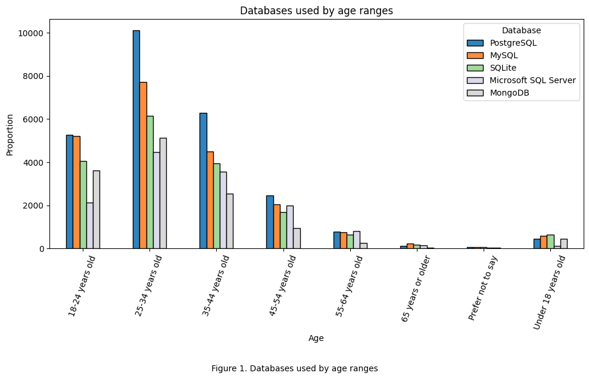

```python
Exp_Age_pivot_table.plot(kind='bar', stacked=False, figsize=(10, 6), colormap='tab20c', edgecolor = 'black')#Plots a bar chart with custom style.

plt.title('Databases used by age ranges')  # Set plot title
plt.ylabel('Proportion')  # Set y-axis label
plt.xlabel('Age') # Set x-axis label
plt.legend(title='Database') #Adds a legend with the title 'Database'.
plt.tight_layout()  # Adjust layout spacing
plt.xticks(rotation=70)  # Rotate x-axis labels
plt.figtext(0.5, -0.05,'Figure 1. Databases used by age ranges', # Adds centered caption below the plot
            wrap=True, horizontalalignment='center', fontsize=10)
plt.show()  # Display the plot
```

## Choropleth Map: Number of Developers by Country

We calculate the number of survey respondents (developers) from each country and visualize the results using a choropleth map.

- The `Country` column is used to identify geographic locations.
- The `Developer_Count` column represents the number of developers per country.
- A `plotly.express` choropleth is used for an interactive world map visualization, with a continuous Viridis color scale to represent density.

This map helps identify where most developers in the dataset are located geographically.

```python
country_counts = df['Country'].value_counts().reset_index()  # Get counts of unique values
country_counts.columns = ['Country', 'Developer_Count']#Renames columns to 'Country' and 'Developer_Count'.

fig = px.choropleth( #Creates a choropleth map of developers by country.
    country_counts,
    locations='Country',
    locationmode='country names',
    color='Developer_Count',
    color_continuous_scale='Viridis',
    title='Number of developers by country'
)
fig.add_annotation( # Adds centered caption below the plot
    text="Figure 2. Number of developers by country based on survey data.",
    xref="paper", yref="paper",
    x=0.5, y=-0.15,
    showarrow=False,
    font=dict(size=12),
    align="center"
)
fig.show()
```

[interactive chart not shown]

### Conclusions: Number of Developers by Country

- The **United States** has the highest number of developers, clearly leading with over **10,000** respondents.
- Other countries with a significant developer presence include **India**, **Germany**, **United Kingdom**, and **Canada**.
- European countries show moderate developer activity, especially in **Western and Central Europe**.
- **South America**, **Africa**, and most parts of **Asia** have lower representation, with smaller clusters in countries like **Brazil**, **Nigeria**, and **Indonesia**.
- The heatmap highlights a digital divide, with **North America**, parts of **Europe**, and **India** dominating in developer count.
- These figures may reflect both population size and internet access, as well as participation in the survey source (likely Stack Overflow or similar).

## Analyzes annual compensation in the top 10 countries with the most developers

We focus on the top 10 countries with the highest number of developers.

- Filter the dataset to include only these countries.
- Calculate the interquartile range (IQR) of the yearly salary (`ConvertedCompYearly`) to detect outliers.
- Remove outliers by keeping salaries within 1.5 * IQR above and below the quartiles.
- Replace long country names with shorter versions for better visualization and readability (e.g., "United Kingdom of Great Britain and Northern Ireland" to "UK").

This cleaning step ensures that extreme salary values do not skew the analysis.

```python
topCountry = df['Country'].value_counts().head(10).index  # Show first 10 rows of DataFrame
topCountry
filtroCtryCCY = df[df['Country'].isin(topCountry)]  # Access DataFrame column


def remove_outliers(df, column):
    Q1 = df[column].quantile(0.25)  # Calculate specified quantile
    Q3 = df[column].quantile(0.75)  # Calculate specified quantile
    IQR = Q3 - Q1           #Calculates the interquartile range (IQR).
    lower = Q1 - 1.5 * IQR  #Calculates the lower bound for outliers.
    upper = Q3 + 1.5 * IQR  #Calculates the upper bound for outliers.

    df = df[(df[column] >= lower)
    & (df[column] <= upper)]#Filters data within the salary bounds to remove outliers.

    return df

filtroCtryCCY = remove_outliers(filtroCtryCCY, 'ConvertedCompYearly')  #Filters data within the salary bounds to remove outliers.


namereplace = {"United Kingdom of Great Britain and Northern Ireland":"UK", "United States of America":"USA"}
filtroCtryCCY.loc[:, 'Country'] = filtroCtryCCY['Country'].replace(namereplace)  # Replace DataFrame names
```

### Boxplot of Annual Compensation in the Top 10 Countries

This boxplot visualizes the distribution of yearly compensation (`ConvertedCompYearly`) for developers in the top 10 countries with the most respondents.

- The x-axis shows the countries.
- The y-axis shows the annual salary, filtered to remove outliers.
- The boxplot highlights the median, quartiles, and potential remaining spread of salaries by country.
- X-axis labels are rotated for better readability.

This visualization helps compare salary distributions across countries while minimizing the effect of extreme values.

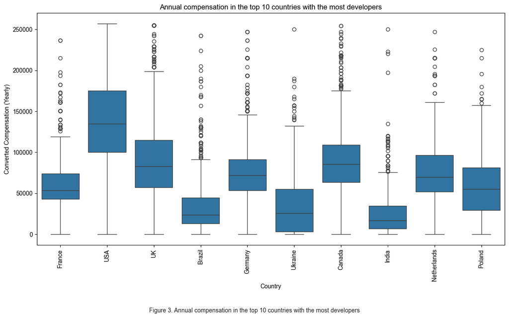

```python
plt.figure(figsize=(12,7))  # Initialize new matplotlib figure

plt.title('Annual compensation in the top 10 countries with the most developers')  # Set plot title
sns.boxplot(x='Country', y='ConvertedCompYearly', data=filtroCtryCCY)  # Draw boxplot
sns.set(style='darkgrid')
plt.ylabel('Converted Compensation (Yearly)')  # Set y-axis label
plt.xticks(rotation=90)  # Rotate x-axis labels
plt.tight_layout()  # Adjust layout spacing
plt.figtext(0.5, -0.05,'Figure 3. Annual compensation in the top 10 countries with the most developers', # Adds centered caption below the plot
            wrap=True, horizontalalignment='center', fontsize=10)
plt.show()  # Display the plot
```

## Bar Plot: Annual Compensation by Work Modality

We analyze how yearly compensation (`ConvertedCompYearly`) varies depending on whether developers work remotely or not.

- The dataset is filtered to remove outliers in compensation.
- A bar plot shows the average salary for each category of work modality (`RemoteWork`).
- Bars are annotated with their exact average salary values for clarity.
- The y-axis limit is set slightly above the highest average to improve visualization.

This plot helps understand if and how remote work status affects developer compensation.

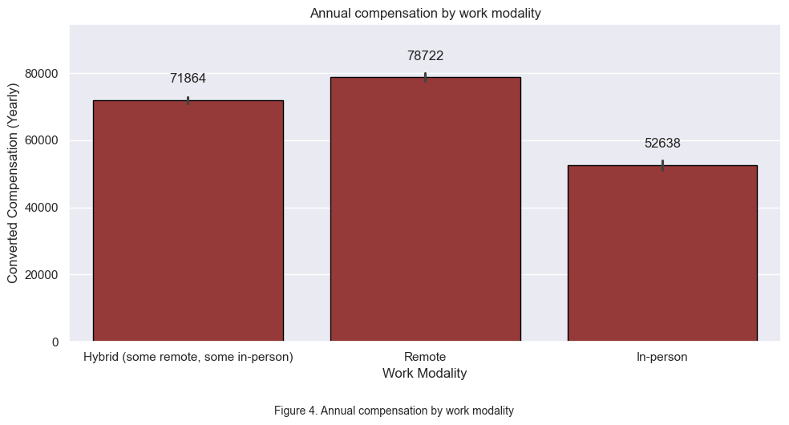

```python
dfRemConv = remove_outliers(df, 'ConvertedCompYearly')  #Filters data within the salary bounds to remove outliers.

plt.figure(figsize=(10,5))  # Initialize new matplotlib figure
plt.title('Annual compensation by work modality')  # Set plot title
ax = sns.barplot(x='RemoteWork', y='ConvertedCompYearly', data=dfRemConv, color='brown', edgecolor='black')#Creates a brown barplot of salary by remote work status.
plt.xlabel('Work Modality') #Set x-axis label
plt.ylabel('Converted Compensation (Yearly)')  # Set y-axis label
max_y = dfRemConv.groupby('RemoteWork')['ConvertedCompYearly'].mean().max() #Finds the highest average salary by remote work group.
ax.set_ylim(0, max_y * 1.2) #Sets y-axis limit slightly above the max average salary.

for bar in ax.patches:
    ax.text(bar.get_x() + bar.get_width()/2, bar.get_height() + 4500, f'{bar.get_height():.0f}', ha='center', va='bottom') #Adds value labels above each bar in the plot.

plt.figtext(0.5, -0.05,'Figure 4. Annual compensation by work modality', # Adds centered caption below the plot
            wrap=True, horizontalalignment='center', fontsize=10)
plt.tight_layout()  # Adjust layout spacing
plt.show()  # Display the plot
```

### Conclusions: Annual Compensation by Work Modality

- **Remote workers** receive the highest average annual compensation at **$78,722**, highlighting the financial advantage of fully remote positions.
- **Hybrid workers** (those with a mix of remote and in-person work) earn slightly less, with an average salary of **$71,864**, indicating some flexibility may still yield competitive pay.
- **In-person workers** report the lowest average annual compensation at **$52,638**, showing a significant gap compared to remote roles — roughly **33% less** than remote counterparts.
- The data suggests a clear trend: **greater flexibility in work location is associated with higher compensation**.
- These results may reflect broader market demand, talent distribution, or cost-of-living adjustments that favor remote work arrangements.

## Analysis and Visualization of Programming Languages Used Across Countries

- We select respondents programming languages (`LanguageHaveWorkedWith`) and their countries.
- Missing values are dropped to ensure clean data processing and accurate visualization:
  - Null values in either column would interfere with text splitting, row expansion, grouping, and plotting.
  - Dropping them prevents errors and avoids introducing meaningless entries (e.g., blank countries or languages).
- Languages are split into individual entries for each developer.
- We focus on the top 10 most used programming languages and the top 20 countries with the most responses.
- Data is grouped by country and language to count occurrences.
- We calculate and print:
  - The most popular language and its percentage of total responses.
  - The combined percentage of the top 10 languages.
- A bubble plot visualizes the frequency of languages used per country:
  - The size and color of each bubble represent how many developers in that country use the language.
  - X-axis shows programming languages, y-axis shows countries.

This plot provides an intuitive overview of programming language popularity and distribution across different countries.

```
The top 1 language is JavaScript with 11.6% and the sum of the top 10 most used languages is 72.9%
```

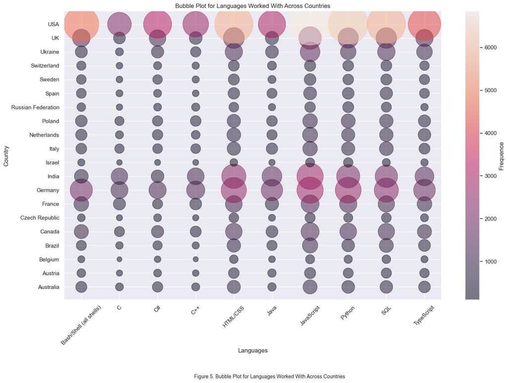

```python
dfProgram = df[['LanguageHaveWorkedWith', 'Country']].dropna()  #Selects language and country columns, drops missing values.
dfProgram['LanguageHaveWorkedWith'] = dfProgram['LanguageHaveWorkedWith'].str.split(';') #Splits languages into lists by semicolon.
dfProgram = dfProgram.explode('LanguageHaveWorkedWith') #Expands list of languages into separate rows.

filtro = dfProgram['LanguageHaveWorkedWith'].value_counts().sort_values(ascending=False).head(10).index #Gets top 10 most used languages.

dfProgram_filter = dfProgram[dfProgram['LanguageHaveWorkedWith'].isin(filtro)] #Filters to keep only the top 10 languages
filtro2 = dfProgram_filter['Country'].value_counts().sort_values(ascending=False).head(20).index  #Gets top 20 countries by count.
dfProgram_filter = dfProgram_filter[dfProgram_filter['Country'].isin(filtro2)] #Filters to keep only the top 20 countries.

grupo = dfProgram_filter.groupby(['Country', 'LanguageHaveWorkedWith']).size().reset_index(name='count') #Groups by country and language, counts occurrences
grupo = grupo.replace(namereplace)  # Replace DataFrame names


LangPorcentage = dfProgram.groupby(['Country', 'LanguageHaveWorkedWith']).size().reset_index(name='count')
LangPorcentage = LangPorcentage[['LanguageHaveWorkedWith', 'count']].groupby('LanguageHaveWorkedWith').sum() \
.sort_values(['count'], ascending=False).reset_index()
TotalP = LangPorcentage['count'].sum()
Top1 = LangPorcentage.iloc[0,1]/TotalP * 100
Top10_total = (LangPorcentage['count'].iloc[:10].sum() / TotalP) * 100
print(f'\033[1mThe top 1 language is {LangPorcentage.iloc[0, 0]} with {Top1:.1f}% \
and the sum of the top 10 most used languages is {Top10_total:.1f}%\033[0m')
print('')

plt.figure(figsize=(15,10))  # Initialize new matplotlib figure
plt.scatter(
    grupo['LanguageHaveWorkedWith'],
    grupo['Country'],
    s=grupo['count'],
    c=grupo['count'],
    alpha = 0.5
)
plt.title('Bubble Plot for Languages Worked With Across Countries')  # Set plot title
plt.xlabel('Languages') # Set x-axis label
plt.ylabel('Country')  # Set y-axis label
plt.xticks(rotation = 45)  # Rotate x-axis labels
plt.tight_layout()  # Adjust layout spacing
plt.colorbar(label='Frequence') #Adds a colorbar labeled 'Frequence'.
plt.figtext(0.5, -0.05,'Figure 5. Bubble Plot for Languages Worked With Across Countries', # Adds centered caption below the plot
            wrap=True, horizontalalignment='center', fontsize=10)
plt.show()  # Display the plot
```

## Analysis of Desired Programming Languages Across Countries

- We extract respondents desired programming languages to work with (`LanguageWantToWorkWith`) along with their countries.
- Missing values are dropped to ensure reliable data transformation and visualization:
  - Null values would break text processing (e.g., splitting) and cause issues in the plot (e.g., blank axes labels).
- Languages are split into individual entries.
- The focus is on the top 10 most desired languages and the top 20 countries with the highest number of responses.
- Data is grouped by country and desired language to count how many developers want to work with each language.

This data preparation sets the stage for visualizing developer preferences for programming languages by country.

```python
dfLW = df[['LanguageWantToWorkWith', 'Country']].dropna() #Selects desired language and country columns, drops missing values.
dfLW['LanguageWantToWorkWith'] = dfLW['LanguageWantToWorkWith'].str.split(';') #Splits desired languages into lists by semicolon.
dfLW = dfLW.explode('LanguageWantToWorkWith') #Expands desired languages into separate rows.

filtroLanguages = dfLW['LanguageWantToWorkWith'].value_counts().sort_values(ascending=False).head(10).index #Gets top 10 desired languages.

dfLW = dfLW[dfLW['LanguageWantToWorkWith'].isin(filtroLanguages)] #Filters to keep only the top 10 desired languages.
dfLW = dfLW[dfLW['Country'].isin(filtro2)] #Filters to keep only the top 20 countries.

group = dfLW.groupby(['Country', 'LanguageWantToWorkWith']).size().reset_index(name='count').replace(namereplace) #Groups by country and desired language, counts, and replaces names.
```

### Bubble Plot: Desired Programming Languages Across Countries

This bubble plot visualizes the distribution of the top 10 programming languages developers want to work with, across the top 20 countries.

- The size and color of each bubble represent the number of developers in a country interested in a particular language.
- The x-axis shows the programming languages.
- The y-axis shows the countries.
- X-axis labels are rotated for better readability.
- A colorbar indicates the frequency scale.

This plot helps reveal trends and preferences in programming languages developers aspire to work with worldwide.

[figure not shown]

```python
plt.figure(figsize=(15,10))  # Initialize new matplotlib figure
plt.scatter(
    group['LanguageWantToWorkWith'],
    group['Country'],
    s=group['count'],
    c=group['count'],
    alpha = 0.5
)
plt.title('Bubble Plot for Databases Wanted Across Countries', fontsize=16)  # Set plot title
plt.xlabel('Languages') #Set x-axis label
plt.ylabel('Country')  # Set y-axis label
plt.xticks(rotation = 45)  # Rotate x-axis labels
plt.tight_layout()  # Adjust layout spacing
plt.colorbar(label='Frequence')
plt.figtext(0.5, -0.05,'Figure 6. Bubble Plot for Databases Wanted Across Countries', # Adds centered caption below the plot
            wrap=True, horizontalalignment='center', fontsize=13)
plt.show()  # Display the plot
```

## Relationship Between Work Experience and Annual Salary

- We select work experience (`WorkExp`) and yearly compensation (`ConvertedCompYearly`), dropping missing values:
  - Null values are removed to ensure valid numerical operations such as averaging and percentage calculations.
  - Keeping them would interfere with statistical calculations and plot accuracy.
- Outliers in salary are removed using previously calculated salary bounds (`lower` and `upper`).
- The average annual salary is calculated for each year of experience.
- The data is sorted by years of experience.
- We compute and print the total percentage increase in salary from year 0 to year 5.
- A scatter plot visualizes the relationship between years of experience and average annual salary.

This analysis helps illustrate how salary tends to increase with work experience.

[output not shown]

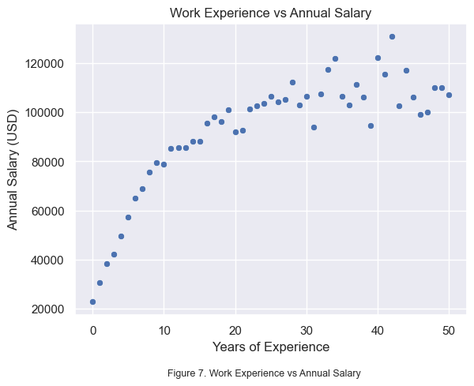

```python
dfExpSalarie = df[['WorkExp', 'ConvertedCompYearly']]
dfExpSalarie = dfExpSalarie.dropna()
dfExpSalarie_outliers = remove_outliers(dfExpSalarie, 'ConvertedCompYearly')  #Filters data within the salary bounds to remove outliers.
groupExpSalarie = dfExpSalarie_outliers.groupby('WorkExp')['ConvertedCompYearly'].mean().reset_index()

groupExpSalarie = groupExpSalarie.sort_values('WorkExp')

initial_salary = groupExpSalarie.loc[groupExpSalarie['WorkExp'] == 0, 'ConvertedCompYearly'].values[0]
salary_year_5 = groupExpSalarie.loc[groupExpSalarie['WorkExp'] == 5, 'ConvertedCompYearly'].values[0]

total_pct_increase = ((salary_year_5 - initial_salary) / initial_salary) * 100

print(f"Total salary increase from year 1 to year 5: {total_pct_increase:.2f}%")

sns.scatterplot(data=groupExpSalarie, x='WorkExp', y='ConvertedCompYearly')
plt.title('Work Experience vs Annual Salary')
plt.xlabel('Years of Experience')
plt.ylabel('Annual Salary (USD)')
plt.figtext(0.5, -0.05,'Figure 7. Work Experience vs Annual Salary', # Adds centered caption below the plot
            wrap=True, horizontalalignment='center', fontsize=9)
plt.show()
```

## Analysis of Desired Web Frameworks

- We extract the `WebframeWantToWorkWith` column, which lists the web frameworks developers want to work with.
- Missing values are dropped to ensure proper data processing and accurate results:
  - Null values would cause errors during string splitting and row expansion, and would distort framework counts.
- Frameworks are split into individual entries.
- The data is exploded so each framework appears in its own row.
- We count the occurrences of each framework and identify the top 10 most desired ones.
- The counts of all other frameworks beyond the top 10 are summed into an "Others" category.
- Labels and sizes for a potential pie or bar chart are prepared, including the "Others" category.

This preparation helps visualize the popularity of web frameworks among developers.

```python
dfWeb_Frame = df['WebframeWantToWorkWith'].dropna().str.split(';') #Splits desired web frameworks into lists, drops missing values.
dfWeb_Frame = dfWeb_Frame.explode() #Expands desired web frameworks into separate rows.

top = dfWeb_Frame.value_counts() #Counts occurrences of each web framework.
top5 = top.head(10) #Selects the top 10 most wanted web frameworks.
others = top[10:].sum() #Sums counts of web frameworks outside the top 10.

labels = top5.index.tolist() + ['Others'] #Creates labels list with top 10 and 'Others'.
sizes = top5.values.tolist() + [others] #Creates sizes list with top 10 counts plus 'Others' sum.
```

### Pie Chart: Preferred Web Frameworks (Top 10 + Others)

This chart provides a clear overview of web framework preferences in the developer community.

[figure not shown]

```python
plt.figure(figsize=(10, 6))  # Initialize new matplotlib figure
patches, texts, autotexts = plt.pie(
    sizes,
    labels=labels,
    autopct='%1.1f%%',
    startangle=140,
    wedgeprops={'edgecolor': 'black'}
)

for text in texts:
    text.set_fontsize(11)
for autotext in autotexts:
    autotext.set_fontsize(11)
    autotext.set_color('white')

plt.title('Pie Chart of Preferred Web Frameworks (Top 5 + Others)', fontsize=14)  # Set plot title
plt.axis('equal')  #Sets plot aspect ratio to be equal
plt.tight_layout()  # Adjust layout spacing
plt.legend(labels, loc='upper right') #Adds a legend with labels in the upper right corner.
plt.style.use('Solarize_Light2') #Applies the 'Solarize_Light2' plot style.
plt.figtext(0.5, -0.05,'Figure 8. Pie Chart of Preferred Web Frameworks', # Adds centered caption below the plot
            wrap=True, horizontalalignment='center', fontsize=10)
plt.show()  # Display the plot
```

### Conclusions: Preferred Web Frameworks

- **React** is the most preferred web framework, accounting for **11.6%** of respondents' preferences among the top listed frameworks.
- **Node.js** follows closely with **11.1%**, showing strong popularity for backend JavaScript development.
- **Next.js** and **Vue.js** maintain solid positions with **6.4%** and **5.7%** respectively, indicating rising interest in modern, flexible frontend frameworks.
- **ASP.NET Core** (5.2%) and **Angular** (4.8%) continue to hold relevance, especially among enterprise developers.
- Newer or niche frameworks such as **Svelte** (4.0%), **Spring Boot** (3.8%), and **Django** (3.7%) also show steady adoption, suggesting diversified ecosystem preferences.
- The **"Others"** category, comprising **39.6%**, indicates a broad variety of frameworks in use beyond the top 10, reflecting fragmentation and specialization in web development technologies.
- Overall, JavaScript-based frameworks dominate the top spots, emphasizing its central role in modern web development across both frontend and backend.

## Line Plot: Average Annual Compensation by Age Group

- We filter the dataset to include only respondents with yearly compensation (`ConvertedCompYearly`) within the previously calculated salary bounds to remove outliers.
- After filtering, we retrieve the unique ages present in this cleaned dataset.

This step ensures subsequent analyses consider only valid salary data and identifies the range of respondent ages available for further study.

```python
dfAC = remove_outliers(df, 'ConvertedCompYearly')  #Filters data within the salary bounds to remove outliers.

dfAC['Age'].unique() #Gets unique ages in the filtered data.
```

```
array(['18-24 years old', '25-34 years old', '35-44 years old',
       '45-54 years old', '55-64 years old', '65 years or older',
       'Under 18 years old', 'Prefer not to say'], dtype=object)
```

### Cleaning and Transforming Age Data for Salary Analysis

- Remove respondents who chose "Prefer not to say" or are under 18 years old.
- Clean the `Age` column by removing text such as "years old" or "years or older".
- Split age ranges (e.g., "25-29") into lists and calculate the average age for each range.
- Drop rows with missing values in `Age` or `ConvertedCompYearly` to ensure accurate calculations:
  - Null values in these columns would lead to incorrect mean salary calculations and potentially cause missing or misleading points in the visualization.
- Group the cleaned data by average age and calculate the mean yearly compensation for each age group.

This transformation allows a more precise analysis of salary trends across continuous age values rather than categorical ranges.

```python
dfAC = dfAC[~dfAC['Age'].isin(['Prefer not to say', 'Under 18 years old'])].copy() #Removes entries with 'Prefer not to say' or 'Under 18 years old' ages.
dfAC['Age'] = dfAC['Age'].str.replace(r' years old| years or older', '', regex=True) #Removes text like 'years old' from the Age values.
dfAC['Age'] = dfAC['Age'].str.split('-') #Splits Age values into lists by hyphen.
dfAC['Age'] = dfAC['Age'].apply(lambda x: sum([float(i) for i in x]) / len(x) if isinstance(x, list) else np.nan) #Calculates average age from age ranges.

dfAC = dfAC.dropna(subset=['Age', 'ConvertedCompYearly'])
group2 = dfAC.groupby('Age')['ConvertedCompYearly'].mean().reset_index() #Calculates average salary by age group.
```

### Line Plot: Relationship Between Age and Annual Compensation

- This line plot shows the average yearly compensation (`ConvertedCompYearly`) across different ages.
- Markers highlight individual data points for each age.
- The plot includes descriptive axis labels and a clear title.
- Layout settings enhance readability with adjusted size and font sizes.

This visualization helps observe trends and patterns in how salary varies with age.

```python
fig = px.line(group2,        #Creates a line plot of average salary by age with markers and labels.
              x='Age',
              y='ConvertedCompYearly',
              markers=True,
              title='Relationship Between Age and Converted Yearly Compensation',
              labels={
                  'Age': 'Age',
                  'ConvertedCompYearly': 'Converted Compensation (Yearly)'
              })

fig.update_layout(       #Updates plot layout with size and font settings.
    width = 900,
    height = 400,
    title_font_size=18,
    xaxis_title_font_size=14,
    yaxis_title_font_size=14,
    margin=dict(t=80, b=80)

)

fig.add_annotation(
    text="Figure 9. Relationship Between Age and Converted Yearly Compensation", # Adds centered caption below the plot
    xref="paper", yref="paper",
    x=0.5, y=-.43,
    font=dict(size=12),
    align="center"
)
fig.show()
```

[interactive chart not shown]

### Conclusions: Age vs Annual Compensation

- **Annual compensation increases steadily with age**, particularly from **20 to 50 years old**, suggesting consistent salary growth throughout early and mid-career stages.
- The most **significant salary jump** appears between the **20–30 age range**, indicating rapid early-career progression.
- Salaries appear to **peak around age 60**, reaching just above **$110,000 USD** on average.
- After **age 60**, there is a **slight decline** in compensation, possibly due to transitions into part-time roles, retirement plans, or advisory positions.
- Overall, age shows a **positive correlation with earnings** up to a point, reinforcing the value of experience but also hinting at a plateau in later years.
- These trends align closely with the patterns observed in the **Work Experience vs Salary** plot, emphasizing long-term career growth followed by stabilization.

## Average Salary by Education Level

- Filter the dataset to include only salaries within the predefined bounds to remove outliers.
- Drop rows with missing values in `EdLevel` or `ConvertedCompYearly` to ensure accurate average salary calculations and avoid errors in grouping and plotting.
- Calculate the average yearly compensation (`ConvertedCompYearly`) for each education level (`EdLevel`).
- Replace long or complex education level names with simplified labels for better readability in plots.

This preparation facilitates a clear comparison of how education level correlates with average salary.

```python
dfEd = remove_outliers(df, 'ConvertedCompYearly')  #Filters data within the salary bounds to remove outliers.
dfEd = dfEd.dropna(subset=['EdLevel', 'ConvertedCompYearly'])
group3 = dfEd.groupby('EdLevel')['ConvertedCompYearly'].mean().reset_index() #Calculates average salary by education level.

Edlvlnames = {
    'Associate degree (A.A., A.S., etc.)': 'Associate degree',
    'Bachelor’s degree (B.A., B.S., B.Eng., etc.)': 'Bachelor’s degree',
    'Master’s degree (M.A., M.S., M.Eng., MBA, etc.)': 'Master’s degree',
    'Some college/university study without earning a degree': 'Some college, no degree',
    'Secondary school (e.g. American high school, German Realschule or Gymnasium, etc.)':'Secondary school',
    'Professional degree (JD, MD, Ph.D, Ed.D, etc.)':'Professional degree'

}
group3 = group3.replace(Edlvlnames)  # Replace DataFrame values
```

### Line Plot: Education Level vs Annual Compensation

- This line plot visualizes the average yearly compensation by education level with markers for each data point.
- Axis labels and a descriptive title improve clarity.
- The x-axis labels are rotated for better readability due to long category names.
- The percentage difference in salary between holders of a professional degree and those with only secondary education is calculated and printed.
- The plot layout is adjusted for size and font for better presentation.

This analysis highlights the impact of education level on annual compensation, showing significant salary differences across education tiers.

```python
fig = px.line(group3,       #Creates a line plot of average salary by education level with markers and labels.
              x='EdLevel',
              y='ConvertedCompYearly',
              markers=True,
              title='Relationship Between Education Level and Converted Yearly Compensation',
              labels={
                  'EdLevel': 'Education Level',
                  'ConvertedCompYearly': 'Converted Compensation (Yearly)'
              })

high = group3[group3['EdLevel'] == 'Professional degree']['ConvertedCompYearly'].values[0]
low = group3[group3['EdLevel'] == 'Secondary school']['ConvertedCompYearly'].values[0]

# Calcular el porcentaje
diff_percent = ((high - low) / low) * 100

print(f"Professional degree holders earn {diff_percent:.1f}% more than those with only secondary education.")


fig.update_layout(   #Updates plot layout with size, fonts, and rotated x-axis labels.
    width=1300,
    height=500,
    title_font_size=18,
    xaxis_title_font_size=14,
    yaxis_title_font_size=14,
    xaxis_tickangle=270,
    margin=dict(t=80, b=210)
)
fig.add_annotation( # Adds centered caption below the plot
    text="Figure 10. Relationship Between Education Level and Converted Yearly Compensation",
    xref="paper", yref="paper",
    x=0.5, y=-1.1,
    font=dict(size=12),
    align="center"
)
fig.show()
```

```
Professional degree holders earn 57.4% more than those with only secondary education.
```

[interactive chart not shown]

### Conclusions: Education Level vs Annual Compensation

- **Professional degree holders** report the **highest average annual salary**, surpassing **$80,000 USD**, indicating a strong return on advanced credentials in specific fields.
- **Bachelor's and Master's degree holders** earn similarly, both averaging around **$73,000 USD**, showing that a Master’s degree may not drastically increase salary in all cases.
- Individuals with only **primary or secondary education** report significantly **lower salaries** (around **$52,000** – **$54,000 USD**), highlighting the economic value of higher education.
- Those with **some college but no degree** earn about **$67,000 USD**, suggesting partial post-secondary education still has a positive impact on earnings.
- Interestingly, **Associate degree** holders earn nearly as much as Bachelor’s graduates, with average compensation near **$68,000 USD**.
- The **“Something else”** category has one of the lowest reported salaries (~**$58,000 USD**), possibly due to unconventional or unrecognized education pathways.
- Overall, while **formal education generally correlates with higher compensation**, there are exceptions that may reflect job market realities, specific professional credentials, or industry variation.

## Scatter Plot: Normalized Compensation vs. Coding Experience Colored by Job Satisfaction

- Select relevant columns: `YearsCode`, `ConvertedCompYearly`, and `JobSat`.
- Filter rows to include only salaries within the predefined bounds and drop rows with missing values in any of these columns. This ensures that subsequent data transformations (like extracting numeric values) and visualizations are accurate and not affected by incomplete or missing data, which could cause errors or bias.
- Extract numeric values from the `YearsCode` column, which may contain text, to get the number of years of coding experience.
- Retrieve unique values in the `YearsCode` column to understand the range of coding experience reported.

This step prepares the dataset for analyzing relationships between coding experience, salary, and job satisfaction.

```python
dfC = df[['YearsCode', 'ConvertedCompYearly', 'JobSat']] #Selects years coding, salary, and job satisfaction columns.
dfC = remove_outliers(dfC, 'ConvertedCompYearly')  #Filters data within the salary bounds to remove outliers.
dfC = dfC.dropna(subset=['YearsCode', 'ConvertedCompYearly', 'JobSat'])
print(dfC['YearsCode'].unique()) #Gets unique values in the YearsCode column.
dfC['YearsCode'] = dfC['YearsCode'].str.extract(r'(\d+)') #Extracts the number of years coded from the text.
```

```
['3' '15' '7' '32' '38' '21' '10' '6' '40' '20' '9' '25' '12' '14' '11'
 '16' '18' '28' '37' '30' '47' '17' '36' '19' '24' '2' '5' '34' '23' '26'
 '13' '33' '31' '45' '22' '4' '35' '27' '48' '8' '42' '29'
 'More than 50 years' '39' '43' '44' '50' '1' 'Less than 1 year' '46' '41'
 '49']
```

### Normalizing Data Using Min-Max Scaling

- Initialize a `MinMaxScaler` to normalize data features to a range between 0 and 1.
- Apply the scaler to the dataframe containing years of coding experience, salary, and job satisfaction.
- Create a new dataframe with the scaled values, preserving original column names.

Normalization facilitates comparison and modeling by bringing all variables to the same scale.

```python
scaler = MinMaxScaler() #Initializes a MinMaxScaler for normalization.
dfC_scaled = pd.DataFrame(scaler.fit_transform(dfC), columns=dfC.columns) #Scales all dataframe columns to a 0-1 range.
```

### Scatter Plot: Years of Coding vs. Salary Colored by Job Satisfaction (Normalized)

- Group the normalized data by years of coding experience and calculate mean values.
- Create a scatter plot comparing normalized yearly compensation against normalized years of coding.
- Color each point based on normalized job satisfaction levels, using the 'viridis' colormap.
- Axis labels and title describe the variables and purpose.
- A colorbar shows the gradient for job satisfaction values.

This visualization reveals potential relationships between coding experience, salary, and job satisfaction on a normalized scale.

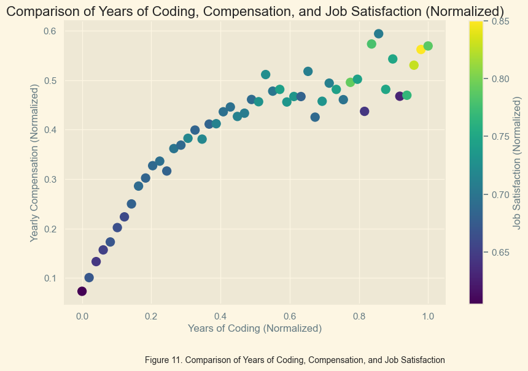

```python
dfC_grouped = dfC_scaled.groupby('YearsCode').mean().reset_index() #Calculates average scaled values grouped by years coding.

plt.figure(figsize=(10, 6))  # Initialize new matplotlib figure
plt.scatter(dfC_grouped['YearsCode'], dfC_grouped['ConvertedCompYearly'], c=dfC_grouped['JobSat'], cmap='viridis', s=100) #Creates a scatter plot of salary vs. years coded, colored by job satisfaction.

plt.xlabel('Years of Coding (Normalized)') # Set x-axis label
plt.ylabel('Yearly Compensation (Normalized)') # Set y-axis label
plt.title('Comparison of Years of Coding, Compensation, and Job Satisfaction (Normalized)')  # Set plot title

plt.colorbar(label='Job Satisfaction (Normalized)') #Adds a colorbar.
plt.figtext(0.5, -0.05,'Figure 11. Comparison of Years of Coding, Compensation, and Job Satisfaction', # Adds centered caption below the plot
            wrap=True, horizontalalignment='center', fontsize=10)
plt.show()  # Display the plot
```

### Conclusions: Coding Experience vs Compensation & Job Satisfaction (Normalized)

- A clear **positive correlation** exists between **years of coding** and **annual compensation**: more experienced coders tend to earn higher salaries.
- **Job satisfaction** also increases moderately with coding experience and compensation, though with some variation.
- The highest job satisfaction (in yellow-green tones) appears toward the upper right, among those with **high compensation and significant experience**.
- Despite normalization, a few outliers show **lower job satisfaction** even at high compensation levels, hinting at non-monetary factors influencing satisfaction.
- The curve flattens slightly after the midpoint, suggesting **diminishing returns** in compensation with increased experience beyond a certain point.
- Normalization allowed for better comparative analysis, though specific numeric values are abstracted.

## FINAL CONCLUSIONS

> These findings provide a holistic view of how experience, age, education, work modality, and regional context influence compensation, preferences, and satisfaction in the software development industry.